# Frothy Head Brewing Analysis

Daniel M. Turner, Pankaj Kumar, Kay Ayala

December 17, 2018

In response to Frothy Head Brewing’s inquiry on beer and breweries, we have examined the provided datasets and produced metrics and visualizations in order to gain insight into beer production in the United States.

We have provided a table and a map of how many breweries there are in each state. From these we can get an idea of the distribution of breweries across the country.

### Breweries per State

| State__________ | Breweries |
| --- | --- |
| AK | 7 |
| AL | 3 |
| AR | 2 |
| AZ | 11 |
| CA | 39 |
| CO | 47 |
| CT | 8 |
| DC | 1 |
| DE | 2 |
| FL | 15 |
| GA | 7 |
| HI | 4 |
| IA | 5 |
| ID | 5 |
| IL | 18 |
| IN | 22 |
| KS | 3 |

| State__________ | Breweries |
| --- | --- |
| KY | 4 |
| LA | 5 |
| MA | 23 |
| MD | 7 |
| ME | 9 |
| MI | 32 |
| MN | 12 |
| MO | 9 |
| MS | 2 |
| MT | 9 |
| NC | 19 |
| ND | 1 |
| NE | 5 |
| NH | 3 |
| NJ | 3 |
| NM | 4 |
| NV | 2 |

[output not shown]

#### Statewise Brewery Map

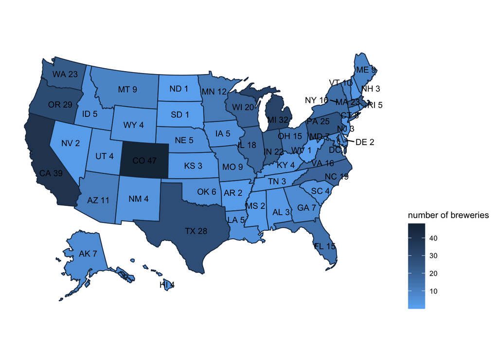

### Dataset

In order to get an idea of the data in the provided datasets we show the head and tail of the merged data.

##### Dataset Head

| Brewery_ID | Beer_Name | Beer_ID | ABV | IBU | Style | Ounces | Brewery_Name | City | State |
| --- | --- | --- | --- | --- | --- | --- | --- | --- | --- |
| 1 | Get Together | 2692 | 0.045 | 50 | American IPA | 16 | NorthGate Brewing | Minneapolis | MN |
| 1 | Maggie’s Leap | 2691 | 0.049 | 26 | Milk / Sweet Stout | 16 | NorthGate Brewing | Minneapolis | MN |
| 1 | Wall’s End | 2690 | 0.048 | 19 | English Brown Ale | 16 | NorthGate Brewing | Minneapolis | MN |
| 1 | Pumpion | 2689 | 0.060 | 38 | Pumpkin Ale | 16 | NorthGate Brewing | Minneapolis | MN |
| 1 | Stronghold | 2688 | 0.060 | 25 | American Porter | 16 | NorthGate Brewing | Minneapolis | MN |
| 1 | Parapet ESB | 2687 | 0.056 | 47 | Extra Special / Strong Bitter (ESB) | 16 | NorthGate Brewing | Minneapolis | MN |

##### Dataset Tail

|  | Brewery_ID | Beer_Name | Beer_ID | ABV | IBU | Style | Ounces | Brewery_Name | City | State |
| --- | --- | --- | --- | --- | --- | --- | --- | --- | --- | --- |
| 2405 | 556 | Pilsner Ukiah | 98 | 0.055 | NA | German Pilsener | 12 | Ukiah Brewing Company | Ukiah | CA |
| 2406 | 557 | Heinnieweisse Weissebier | 52 | 0.049 | NA | Hefeweizen | 12 | Butternuts Beer and Ale | Garrattsville | NY |
| 2407 | 557 | Snapperhead IPA | 51 | 0.068 | NA | American IPA | 12 | Butternuts Beer and Ale | Garrattsville | NY |
| 2408 | 557 | Moo Thunder Stout | 50 | 0.049 | NA | Milk / Sweet Stout | 12 | Butternuts Beer and Ale | Garrattsville | NY |
| 2409 | 557 | Porkslap Pale Ale | 49 | 0.043 | NA | American Pale Ale (APA) | 12 | Butternuts Beer and Ale | Garrattsville | NY |
| 2410 | 558 | Urban Wilderness Pale Ale | 30 | 0.049 | NA | English Pale Ale | 12 | Sleeping Lady Brewing Company | Anchorage | AK |

### Missing Values

It is important to note there are missing values in the data and IBU has the most missing values. This is the sum of missing values for each variable.

|  | Number of Missing Values |
| --- | --- |
| Brewery_ID | 0 |
| Beer_Name | 0 |
| Beer_ID | 0 |
| ABV | 62 |
| IBU | 1005 |
| Style | 0 |
| Ounces | 0 |
| Brewery_Name | 0 |
| City | 0 |
| State | 0 |

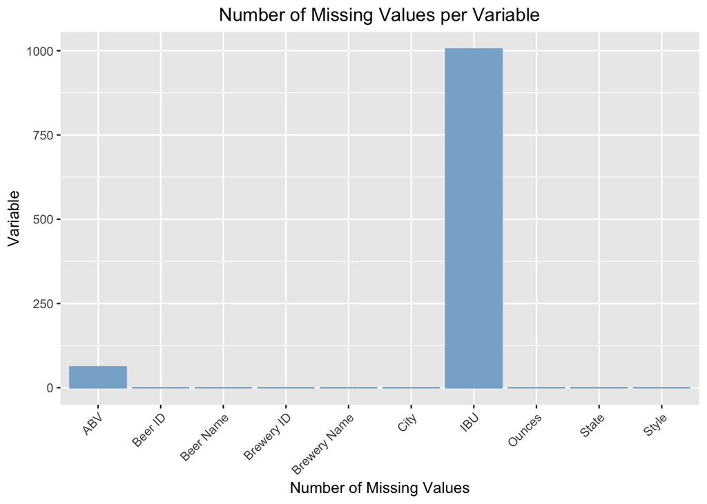

### Alcohol Content Distribution by State

In order to get an idea of what alcohol content and bitterness preferences are by state we provide bar charts of ABV and IBU. This may be of use when considering what type of beers to be making in each state.

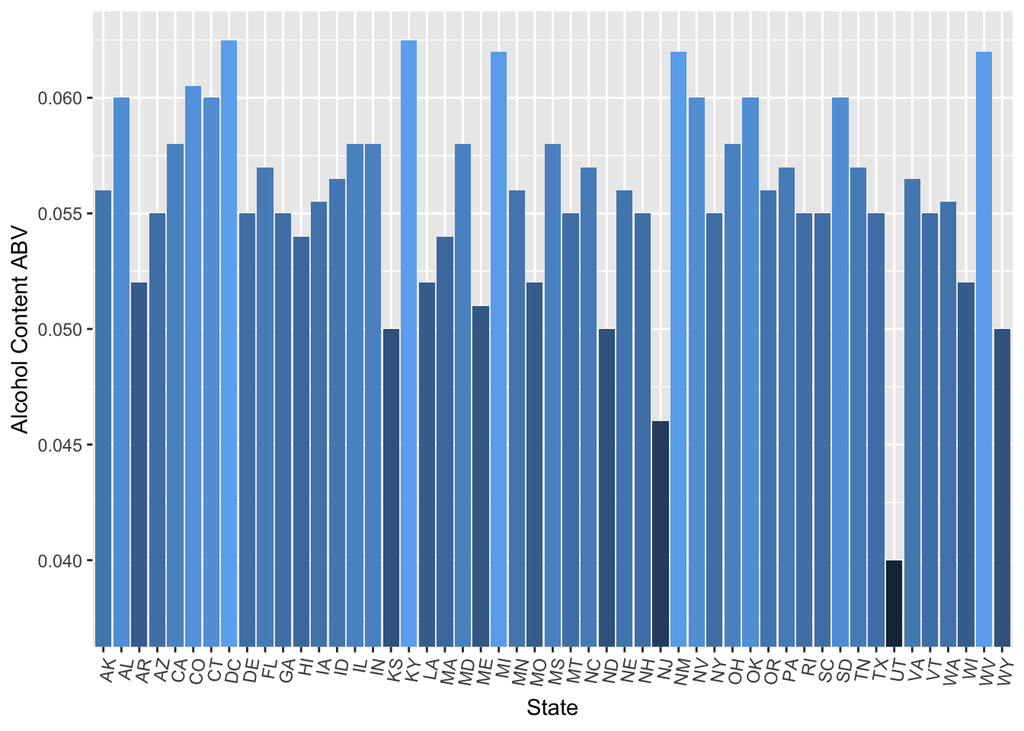

### Bitterness Distribution by State

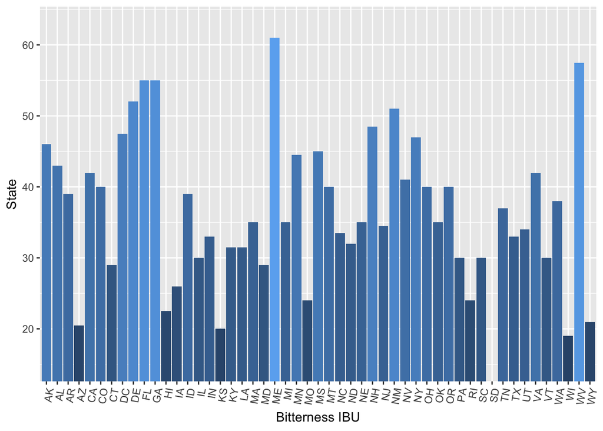

### State with the Most Alcoholic ABV Beer and Spread of Alcohol Content ABV

The state with the most alcoholic beer was Colorado.

|  | Brewery_ID | Beer_Name | Beer_ID | ABV | IBU | Style | Ounces | Brewery_Name | City | State |
| --- | --- | --- | --- | --- | --- | --- | --- | --- | --- | --- |
| 375 | 52 | Lee Hill Series Vol. 5 - Belgian Style Quadrupel Ale | 2565 | 0.128 | NA | Quadrupel (Quad) | 19.2 | Upslope Brewing Company | Boulder | CO |

The most produced beers follow the following spread of alcohol content summary. It would be most recommended to produce beer within the first and third quartiles of alcohol content.

```
##    Min. 1st Qu.  Median    Mean 3rd Qu.    Max.    NA's
## 0.00100 0.05000 0.05600 0.05977 0.06700 0.12800      62
```

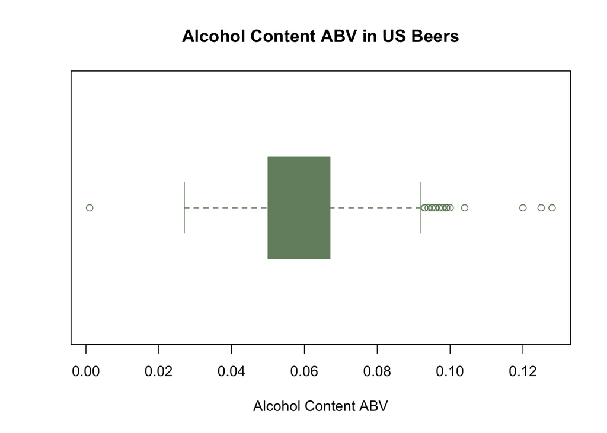

### State with the Most Bitter IBU Beer and Spread of Bitterness Levels IBU

The state with the most bitter beer was Oregon.

|  | Brewery_ID | Beer_Name | Beer_ID | ABV | IBU | Style | Ounces | Brewery_Name | City | State |
| --- | --- | --- | --- | --- | --- | --- | --- | --- | --- | --- |
| 1857 | 375 | Bitter Bitch Imperial IPA | 980 | 0.082 | 138 | American Double / Imperial IPA | 12 | Astoria Brewing Company | Astoria | OR |

```
##    Min. 1st Qu.  Median    Mean 3rd Qu.    Max.    NA's
##    4.00   21.00   35.00   42.71   64.00  138.00    1005
```

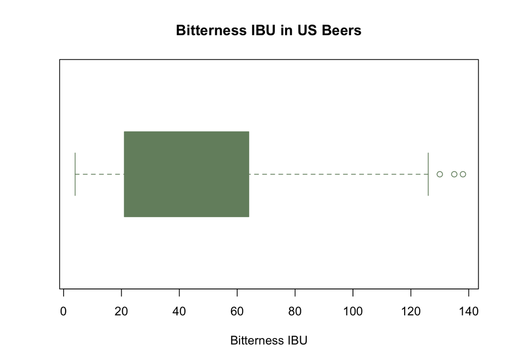

### Relationship between the Bitterness and Alcoholic Content of Each Beer

We looked to see if we could find a relationship between bitterness and alcohol content by producing a scatterplot. More alcoholic beers had a the full range of bitterness, but less alcoholic beers tended to have low bitterness. The data has a moderate linear relationship as can be seen from the Pearson’s Correlation value and the line on the scatter plot.

##### Pearson Correlation between ABV and IBU

```
## [1] 0.6706215
```

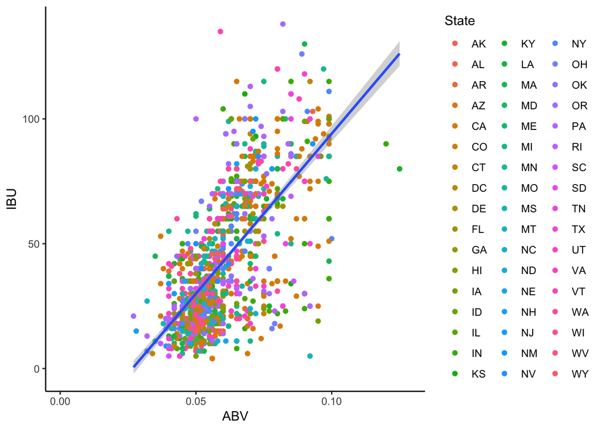